# Walmart - Store Sales Forecasting

We are provided with historical sales data for 45 Walmart stores located in different regions, and each store contains many departments. We target to project the sales for each store. To add to the challenge, selected holiday markdown events are included in the dataset.

There are 45 stores of varying types and sizes.

The data/features: Store; Type; Size; Dept; Date; WeeklySales(training data provided); IsHoliday; Temperature - average temperature in the region; Fuel_price - cost of fuel in the region; MarkDown1; MarkDown2; MarkDown3; MarkDown4; MarkDown5; CPI; Unemployment

Note: MarkDown data is anonymized data related to promotional markdowns that Walmart is running. MarkDown data is only available after Nov 2011, and is not available for all stores all the time. Any missing value is marked with an NA.

The data covers 2010-02-05 to 2012-11-01.

#### Define Environment

### Data Preparation

#### Import data into pandas dataframe

```python
df = pd.read_csv("../data/wm_data.csv") #primary data file

# for john's machine: C:\Users\lohnj\Documents\DataBox\DS_HK_9\data\wm_data.csv
# for others' machines: "wm_data.csv"
```

```python
df.head()
```

|  | Store | Type | Size | Dept | Date | Weekly_Sales | IsHoliday | Temperature | Fuel_Price | MarkDown1 | MarkDown2 | MarkDown3 | MarkDown4 | MarkDown5 | CPI | Unemployment |
| --- | --- | --- | --- | --- | --- | --- | --- | --- | --- | --- | --- | --- | --- | --- | --- | --- |
| 0 | 1 | A | 151315 | 1 | 05/02/2010 | 24924.50 | 0 | 42.31 | 2.572 | NaN | NaN | NaN | NaN | NaN | 211.096358 | 8.106 |
| 1 | 1 | A | 151315 | 1 | 12/02/2010 | 46039.49 | 1 | 38.51 | 2.548 | NaN | NaN | NaN | NaN | NaN | 211.242170 | 8.106 |
| 2 | 1 | A | 151315 | 1 | 19/02/2010 | 41595.55 | 0 | 39.93 | 2.514 | NaN | NaN | NaN | NaN | NaN | 211.289143 | 8.106 |
| 3 | 1 | A | 151315 | 1 | 26/02/2010 | 19403.54 | 0 | 46.63 | 2.561 | NaN | NaN | NaN | NaN | NaN | 211.319643 | 8.106 |
| 4 | 1 | A | 151315 | 1 | 05/03/2010 | 21827.90 | 0 | 46.50 | 2.625 | NaN | NaN | NaN | NaN | NaN | 211.350143 | 8.106 |

```python
df.describe()
```

|  | Store | Size | Dept | Weekly_Sales | IsHoliday | Temperature | Fuel_Price | MarkDown1 | MarkDown2 | MarkDown3 | MarkDown4 | MarkDown5 | CPI | Unemployment |
| --- | --- | --- | --- | --- | --- | --- | --- | --- | --- | --- | --- | --- | --- | --- |
| count | 421570.000000 | 421570.000000 | 421570.000000 | 421570.000000 | 421570.000000 | 421570.000000 | 421570.000000 | 150681.000000 | 111248.000000 | 137091.000000 | 134967.000000 | 151432.000000 | 421570.000000 | 421570.000000 |
| mean | 22.200546 | 136727.915739 | 44.260317 | 15981.258123 | 0.070358 | 60.090059 | 3.361027 | 7246.420196 | 3334.628621 | 1439.421384 | 3383.168256 | 4628.975079 | 171.201947 | 7.960289 |
| std | 12.785297 | 60980.583328 | 30.492054 | 22711.183519 | 0.255750 | 18.447931 | 0.458515 | 8291.221345 | 9475.357325 | 9623.078290 | 6292.384031 | 5962.887455 | 39.159276 | 1.863296 |
| min | 1.000000 | 34875.000000 | 1.000000 | -4988.940000 | 0.000000 | -2.060000 | 2.472000 | 0.270000 | -265.760000 | -29.100000 | 0.220000 | 135.160000 | 126.064000 | 3.879000 |
| 25% | 11.000000 | 93638.000000 | 18.000000 | 2079.650000 | 0.000000 | 46.680000 | 2.933000 | 2240.270000 | 41.600000 | 5.080000 | 504.220000 | 1878.440000 | 132.022667 | 6.891000 |
| 50% | 22.000000 | 140167.000000 | 37.000000 | 7612.030000 | 0.000000 | 62.090000 | 3.452000 | 5347.450000 | 192.000000 | 24.600000 | 1481.310000 | 3359.450000 | 182.318780 | 7.866000 |
| 75% | 33.000000 | 202505.000000 | 74.000000 | 20205.852500 | 0.000000 | 74.280000 | 3.738000 | 9210.900000 | 1926.940000 | 103.990000 | 3595.040000 | 5563.800000 | 212.416993 | 8.572000 |
| max | 45.000000 | 219622.000000 | 99.000000 | 693099.360000 | 1.000000 | 100.140000 | 4.468000 | 88646.760000 | 104519.540000 | 141630.610000 | 67474.850000 | 108519.280000 | 227.232807 | 14.313000 |

```python
df.info()
```

```
<class 'pandas.core.frame.DataFrame'>
Int64Index: 421570 entries, 0 to 421569
Data columns (total 16 columns):
Store           421570 non-null int64
Type            421570 non-null object
Size            421570 non-null int64
Dept            421570 non-null int64
Date            421570 non-null object
Weekly_Sales    421570 non-null float64
IsHoliday       421570 non-null int64
Temperature     421570 non-null float64
Fuel_Price      421570 non-null float64
MarkDown1       150681 non-null float64
MarkDown2       111248 non-null float64
MarkDown3       137091 non-null float64
MarkDown4       134967 non-null float64
MarkDown5       151432 non-null float64
CPI             421570 non-null float64
Unemployment    421570 non-null float64
dtypes: float64(10), int64(4), object(2)
memory usage: 54.7+ MB
```

### Initial Data Analysis

#### All store analysis

#### Sales Performance by Store

```python
trace1 = go.Bar(
    x=totalsales['Store'],
    y=totalsales['Weekly_Sales'],
    name='Store Sales',
    marker=dict(
        color='rgb(253, 194, 13)'
    )
)

data = [trace1]
layout = go.Layout(
    title='Sales by store from 5 Feb 2010 to 1 Nov 2012',
    xaxis=dict(
        tickfont=dict(
            size=14,
            color='rgb(107, 107, 107)'
        )
    ),
    yaxis=dict(
        title='Sales',
        titlefont=dict(
            size=16,
            color='rgb(107, 107, 107)'
        ),
        tickfont=dict(
            size=14,
            color='rgb(107, 107, 107)'
        )
    ),
    legend=dict(
        x=1,
        y=1,
        bgcolor='rgba(255, 255, 255, 0)',
        bordercolor='rgba(255, 255, 255, 0)'
    ),

    barmode='group',
    bargap=0.15,
    bargroupgap=0.1

)
from plotly.offline import iplot
fig = go.Figure(data=data, layout=layout)
plot_url = iplot(fig)
```

[interactive chart not shown]

Observation: Store 20 has the highest sales.

#### Store Size Analysis

```python
trace1 = go.Bar(
    x=totalsales['Store'],
    y=totalsales['storesize'],
    name='Store Size',
    marker=dict(
        color='rgb(253, 126, 13)'
    )
)

data = [trace1]
layout = go.Layout(
    title='Stores Sizes',
    xaxis=dict(
        tickfont=dict(
            size=14,
            color='rgb(107, 107, 107)'
        )
    ),
    yaxis=dict(
        title='Size',
        titlefont=dict(
            size=16,
            color='rgb(107, 107, 107)'
        ),
        tickfont=dict(
            size=14,
            color='rgb(107, 107, 107)'
        )
    ),

    legend=dict(
        x=1,
        y=1,
        bgcolor='rgba(255, 255, 255, 0)',
        bordercolor='rgba(255, 255, 255, 0)'
    ),
    barmode='group',
    bargap=0.15,
    bargroupgap=0.1
    )
from plotly.offline import iplot
fig = go.Figure(data=data, layout=layout)
plot_url = iplot(fig)
```

[interactive chart not shown]

Observation: Store 13 is the largest store.

#### Sales return per store unit

```python
trace1 = go.Bar(
    x=totalsales['Store'],
    y=totalsales['unit_sales'],
    name='Sales return per square meter',
    marker=dict(
        color='rgb(55, 83, 109)'
    )
)

data = [trace1]
layout = go.Layout(
    title='Sales return per square meter for each store',
    xaxis=dict(
        tickfont=dict(
            size=14,
            color='rgb(107, 107, 107)'
        )
    ),
    yaxis=dict(
        title='Size',
        titlefont=dict(
            size=16,
            color='rgb(107, 107, 107)'
        ),
        tickfont=dict(
            size=14,
            color='rgb(107, 107, 107)'
        )
    ),
    legend=dict(
        x=1,
        y=1,
        bgcolor='rgba(255, 255, 255, 0)',
        bordercolor='rgba(255, 255, 255, 0)'
    ),
    barmode='group',
    bargap=0.15,
    bargroupgap=0.1
)
from plotly.offline import iplot
fig = go.Figure(data=data, layout=layout)
plot_url = iplot(fig)
```

[interactive chart not shown]

Observation: Store 10 and Store 43 have highest sales reteurn per store square meter.

#### Would seasonal factor affect the sales a lot?

```python
trace1 = go.Bar(
    x=avgsales_nh['Store'],
    y=avgsales_nh['Weekly_Sales'],
    name='Holiday Sales',
    marker=dict(
        color='rgb(55, 83, 109)'
    )
)
trace2 = go.Bar(
    x=avgstoresize['Store'],
    y=avgstoresize['Weekly_Sales'],
    name='Total Sales',
    marker=dict(
        color='rgb(26, 118, 255)'
    )
)
data = [trace1, trace2]
layout = go.Layout(
    title='Seasonal Sales Contribution',
    xaxis=dict(
        tickfont=dict(
            size=14,
            color='rgb(107, 107, 107)'
        )
    ),
    yaxis=dict(
        title='Sales',
        titlefont=dict(
            size=16,
            color='rgb(107, 107, 107)'
        ),
        tickfont=dict(
            size=14,
            color='rgb(107, 107, 107)'
        )
    ),
    legend=dict(
        x=1,
        y=1,
        bgcolor='rgba(255, 255, 255, 0)',
        bordercolor='rgba(255, 255, 255, 0)'
    ),
    barmode='group',
    bargap=0.15,
    bargroupgap=0.1
)
from plotly.offline import iplot
fig = go.Figure(data=data, layout=layout)
plot_url = iplot(fig)
```

[interactive chart not shown]

Observation: The average daily sales from Holiday is slightly higher then normal days. The difference is not material.

### Selecting Data

Due to the large dataset, we have opted to look at any given specific store "type", any given store itself, and any given department(s), because otherwise, our machines cannot handle the data.

```python
#Constant - can use this to adjust which Store Type to analyse
store_type = 'C'
#Store types are A, B, or C

store_num = 30
#Store numbers 30, 37, 38, 42, 43, 44

dept_num = 1
#department numbers range from 1 to 99
```

```python
df.columns = map(str.lower,df.columns)
```

```python
dfhelper1 = df[(df['type'] == store_type)]
```

```python
dfhelper2 = dfhelper1[(dfhelper1['store'] == store_num)]
#if want to include all stores, then use >= 30
```

```python
dfx = dfhelper2[(dfhelper2['dept'] == dept_num)]
#if want to include all stores, then use >= 1
```

```python
dfx.head()
```

|  | store | type | size | dept | date | weekly_sales | isholiday | temperature | fuel_price | markdown1 | markdown2 | markdown3 | markdown4 | markdown5 | cpi | unemployment |
| --- | --- | --- | --- | --- | --- | --- | --- | --- | --- | --- | --- | --- | --- | --- | --- | --- |
| 286548 | 30 | C | 42988 | 1 | 05/02/2010 | 10158.77 | 0 | 39.05 | 2.572 | NaN | NaN | NaN | NaN | NaN | 210.752605 | 8.324 |
| 286549 | 30 | C | 42988 | 1 | 12/02/2010 | 14346.05 | 1 | 37.77 | 2.548 | NaN | NaN | NaN | NaN | NaN | 210.897994 | 8.324 |
| 286550 | 30 | C | 42988 | 1 | 19/02/2010 | 12321.18 | 0 | 39.75 | 2.514 | NaN | NaN | NaN | NaN | NaN | 210.945160 | 8.324 |
| 286551 | 30 | C | 42988 | 1 | 26/02/2010 | 10099.28 | 0 | 45.31 | 2.561 | NaN | NaN | NaN | NaN | NaN | 210.975957 | 8.324 |
| 286552 | 30 | C | 42988 | 1 | 05/03/2010 | 9719.90 | 0 | 48.61 | 2.625 | NaN | NaN | NaN | NaN | NaN | 211.006754 | 8.324 |

#### Simplifying Dataframe

For purposes of EDA, and as noted above, we have set up the analysis to be "controllable" with respect to what types of stores, which stores, and which departments to analyse. To further clean up the dataframe, we can remove the Type and Size because they are essentially one and the same once a particular Store Type is selected (as above).

```python
#Can remove/drop column 'type' because have established store_type constant above
dfx.drop('type',axis=1,inplace=True)
```

```python
#Can also remove/drop column 'size' since already removed 'type' column
dfx.drop('size',axis=1,inplace=True)
```

In reviewing the data (and included as prompt to the challenge), the mark down data is only available for the last year, so with respect to using them as relevant features for prediction over time, they are not relevant; therefore, we exclude them.

```python
#Remove markdown columns - not enough data/history of information to be useful as feature
dfx.drop(['markdown1', 'markdown2', 'markdown3', 'markdown4', 'markdown5'], axis=1, inplace=True)
```

### Single Store Analysis

```python
#Average sales on non-holidays vs holidays
cols = ['store', 'isholiday', 'weekly_sales']
dfx[cols].groupby(cols[:2]).mean()

#there doesn't seem to be a difference between the average weekly sales for holidays vs non-holidays
```

| store | isholiday | weekly_sales |
| --- | --- | --- |
| 30 | 0 | 9800.426391 |
|  | 1 | 9628.115000 |

On an average basis, there doesn't appear to be a material difference between a week with a holiday or non-holiday weeks.

```python
#Aggregate sales on non-holidays vs holidays
cols = ['store', 'isholiday', 'weekly_sales']
dfx[cols].groupby(cols[:2]).sum()
```

| store | isholiday | weekly_sales |
| --- | --- | --- |
| 30 | 0 | 1303456.71 |
|  | 1 | 96281.15 |

### Exploratory Data Analysis

```python
##dfx.iplot(kind='hist', subplots = True, subplot_titles = True, dimensions = (980,1400))
```

```python
#In the first instance, to explore/observe any patterns, have chosen to plot for one store and one department
#Ideally, would like to "overlay" the various features of temperature, fuel price, cpi, unemployment over the weekly sales plot
#The subplots are helpful when we only plot one store, and one department; as soon as multiple stores/departments are added,
#the data becomes hard to observe

dfx.iplot(kind = 'scatter',
         mode = 'markers',
        # keys = numcols,
         symbol = 'x',
         size = 4,
         x='date',
         subplots = True,
         subplot_titles = True,
         dimensions = (980,1400))
```

[interactive chart not shown]

### Observations

1. With respect to the selected store and department, sales are relatively stable over the time period, but there are visibly some periods of higher than average sales.
2. Temperature fluctuates and does not appear to have an obvious relationship with weekly sales.
3. Fuel price trended upward, from 2011; average weekly sales appeared to have a slightly downward trend co-inciding with fuel price increases.
4. As unemployment decreased, CPI increased, which in theory would have suggested weekly sales to average up; however, as noted above, fuel prices also increased during this time, which may or may not have had downward pressure on sales.

### Univariate Analysis and Multivariate Analysis

```python
dfx.iplot(kind='bar', x='date', y='weekly_sales', dimensions = (1000,400))
```

[interactive chart not shown]

Observation: Sales peak were on 11 May 2010 and 11 Apr 2011.

```python
dfx.iplot(kind = 'scatter',
          mode = 'markers',
          symbol = 'x',
          size = 5,
          x='date',
          y='weekly_sales',
          dimensions = (800,400))
```

[interactive chart not shown]

```python
#Constant - can use this to adjust which Store Type to analyse
z = 'fuel_price'

#control 'z' as: temperature, fuel_price, cpi, unemployment
```

```python
dfx.iplot(kind = 'bubble',
          x='date',
          y = 'weekly_sales',
          size = z,
          dimensions = (800,400))
```

[interactive chart not shown]

### Observations

As mentioned above, the only obvious relationship appears to be between CPI and Unemployment, but neither of these have intuitive relationships with weekly sales over the time period.

## Relationship Exploration

#### Correlationship between the features

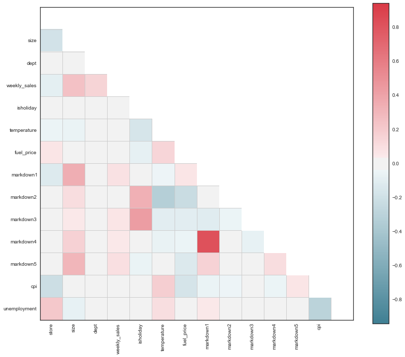

```python
f, ax = plt.subplots(figsize=(12, 12))
cmap = sns.diverging_palette(220, 10, as_cmap=True)
sns.corrplot(df, annot=False, sig_stars=False,
             diag_names=False, cmap=cmap, ax=ax)
f.tight_layout()
```